# complete analysis (without contaminated samples)

Turns out the 8 hopkinsi samples that we ultimately removed were actually contaminated. I will check on the four rosaceus samples as well that looked fishy in the structure plot.

Then I want to do a full analysis similar to `10-complete-downsamp-self-ass..` without these contaminated samples.

NOTE: Fst analysis is in `13-pcas-for-manuscript.Rmd`.

Read in data and libraries

```r
library(tidyverse)
library(rubias)
library(CKMRsim) # add this for the index markers function
# genotypes
genos <- readRDS("../new_baseline_data/processed/called_genos_na_explicit.rds") %>%
  filter(!str_detect(NMFS_DNA_ID, "N")) # remove Lorne's ambiguous yelloweye samples
labels <- readRDS("../new_baseline_data/processed/label-tibble.rds")
samples <- readRDS("../new_baseline_data/processed/sample-sheet-tibble.rds")
# meta data
meta <- readRDS("../new_baseline_data/processed/meta-data-tibble.rds") %>%
  select(1,8,13,22) %>% # just the relevant columns for now
  mutate(REPORTED_LIFE_STAGE = ifelse(REPORTED_LIFE_STAGE == "Adult", "ADULT", REPORTED_LIFE_STAGE)) %>%   # make the syntax consistent
   mutate(REPORTED_LIFE_STAGE = ifelse(REPORTED_LIFE_STAGE == "Juvenile", "JUVENILE", REPORTED_LIFE_STAGE)) %>%
  mutate(REPORTED_LIFE_STAGE = ifelse(is.na(REPORTED_LIFE_STAGE), "UNKNOWN", REPORTED_LIFE_STAGE)) # be explict about NAs
# there are thousands of nmfs ids with two metadata entries
# remove duplicates
meta <- meta %>%
  distinct()

# make the gtseq run a consistent data type
labels$gtseq_run <- as.integer(labels$gtseq_run)
```

Remove contaminated hopkinsi

```r
# nmfs ids for those contaminated fish
hopis <- c("R010376", "R010374", "R010377", "R010375", "R010372", "R010370", "R010371", "R010373")
hopkis <- as.tibble(hopis) %>%
  rename(NMFS_DNA_ID = value)
# remove those ids from the genos file
genos <- genos %>%
  anti_join(., hopkis)
```

There are some species names that need to be modified because there is the “S” for Sebastes in front of the name:

```r
# make species labels consistent
labels1 <- labels %>%
  mutate(species = ifelse(grepl("S", species), (gsub("S", "", species)), species))
```

Excluding marmoratus, that leaves 58 species (which one wasn’t included in future analyses? Probably brevispinis)

Now join the data

```r
# I can join these datasets by gtseq run and id
genos_spp <- labels1 %>%
  left_join(., genos, by = c("id", "gtseq_run")) %>%
  select(gtseq_run, id, species, everything())
# how many samples?
genos_spp %>%
  select(id, gtseq_run) %>%
  unique()
```

| id | gtseq_run |
| --- | --- |
| s769 | 11 |
| s770 | 11 |
| s771 | 11 |
| s772 | 11 |
| s773 | 11 |
| s774 | 11 |
| s775 | 11 |
| s776 | 11 |
| s777 | 11 |
| s778 | 11 |

[output cut: 990 more lines]

1,898 samples (but these are not wholly unique - some are duplicates from different sequencing runs).

With the species information tacked on, I should be able to organize my data table for self-assignment using rubias.

## Some initial filters

### Take highest read-depth call for multiply-genotyped DNA_IDs

I’m not sure if there are any of these, but best to leave it in here…

Now, here is a harder operation: if an individual is multiply-genotyped, take the genotype with the highest total read depth.

```r
# slow-ish function to get the total read depth column
tdepth <- function(a, d) {
  if(any(is.na(a))) {
    return(NA)
  }
  if(a[1]==a[2]) {
    return(d[1])
  } else {
    return(d[1] + d[2])
  }

}
# this takes the highest read-depth instance of each duplicately-genotyped individual.
geno_one_each <- genos_spp %>%
  group_by(NMFS_DNA_ID, species, locus, gtseq_run) %>%
  mutate(total_depth = tdepth(allele, depth)) %>%
  ungroup() %>%
  arrange(NMFS_DNA_ID, species, locus, total_depth, gtseq_run, depth) %>%
  group_by(NMFS_DNA_ID, species, locus) %>%
  mutate(rank = 1:n()) %>%
  #ungroup() %>%
  filter(rank <= 2) %>%
  filter(!is.na(NMFS_DNA_ID)) # remove the samples from Lorne without IDs

# how many samples now?
geno_one_each %>%
  group_by(NMFS_DNA_ID) %>%
  select(gtseq_run, id, species, NMFS_DNA_ID) %>%
  unique() %>%
  tally() %>%
  arrange(desc(n))
```

| NMFS_DNA_ID | n |
| --- | --- |
| R001570 | 2 |
| R011748 | 2 |
| R011993 | 2 |
| R012111 | 2 |
| R012125 | 2 |
| R012201 | 2 |
| R012216 | 2 |
| R000851 | 1 |
| R000852 | 1 |
| R000853 | 1 |

[output cut: 990 more lines]

Seven NMFS_DNA_IDs occur twice - so we narrowed those duplicates down for a total of 1,787 samples (after removing the 8 contaminated hopkinsi).

```r
geno_one_each %>%
  group_by(NMFS_DNA_ID) %>%
  select(species, NMFS_DNA_ID) %>%
  unique() %>%
  ungroup() %>%
  group_by(species) %>%
  tally() %>%
  arrange(desc(n))
```

| species | n |
| --- | --- |
| atrovirens | 242 |
| carnatus | 228 |
| chrysomelas | 122 |
| melanops | 82 |
| goodei | 66 |
| levis | 65 |
| ensifer | 36 |
| ovalis | 36 |
| paucispinis | 33 |
| serranoides | 33 |

[output cut: 49 more lines]

59 species?! Again, still including marmoratus and brevispinis. I exclude brevispinis later, along with helvomaculatus and simulator, so I will remove marmoratus now.

```r
# remove the genotypes for Scorpaenichthys marmoratus
geno_one_each2 <- geno_one_each %>%
  filter(species != "marmoratus")
```

Total number of samples for manuscript:

```r
geno_one_each2 %>%
  ungroup() %>%
  select(NMFS_DNA_ID) %>%
  unique()
```

| NMFS_DNA_ID |
| --- |
| R000851 |
| R000852 |
| R000853 |
| R000854 |
| R000856 |
| R000857 |
| R000858 |
| R000859 |
| R000860 |
| R000861 |

[output cut: 990 more lines]

1,785 samples.

species affiliations:

```r
spp_tally <- geno_one_each2 %>%
  ungroup() %>%
  select(NMFS_DNA_ID, species) %>%
  unique() %>%
  ungroup() %>%
  group_by(species) %>%
  tally() %>%
  arrange(desc(n))
spp_tally %>%
  write_csv("csv_outputs/58species_tally_for_manuscript.csv")
```

58 species with the following number of samples per species

### Remove the 6 loci which Hayley has been removing

How much missing data at the six loci?

```r
# to_remove %>%
#   ungroup() %>%
#   left_join(geno_one_each2) %>%
#   select(locus, species, NMFS_DNA_ID, allele) %>%
#   filter(is.na(allele)) %>%
#   unique() %>%
#   group_by(locus, species) %>%
#   tally() %>%
#   select(locus, species) %>%
#   ungroup() %>%
#   group_by(locus) %>%
#   tally()
```

```r
# read in a list of the 6 loci
to_remove <- read_csv("../data/loci_to_remove.csv")
# only keep the loci that are not those 6
keepers <- geno_one_each2 %>%
  anti_join(., to_remove, by = "locus")
# that should leave 90 loci
```

### Toss out indivs with missing data at more than 25 loci

Now, toss out any individual with fewer than 65 non-missing loci

```r
no_hi_missers <- keepers %>%
  group_by(NMFS_DNA_ID, gtseq_run) %>%
  filter(sum(!is.na(allele)) >= (65*2))
```

So, we started with 1787 and after filtering out indivs with fewer than 65 genotyped loci, we were left with 1649 individuals. Those are the ones that we will run through rubias to identify to species.

1787 down to 1649 after removing individuals with too much missing data. Write a file with the species affiliations for the samples at this stage:

```r
# modify the sample column
spp_tally <- spp_tally %>%
  rename(n_genotyped = n)
```

```r
# post-filtering samples
spp_tally2 <- no_hi_missers %>%
  ungroup() %>%
  select(species, NMFS_DNA_ID) %>%
  unique() %>%
  group_by(species) %>%
  tally() %>%
  arrange(desc(n)) %>%
  rename(post_filter = n) %>%
  right_join(., spp_tally) %>%
  select(species, n_genotyped, post_filter)
```

Make integers out of the alleles

```r
rock2 <- no_hi_missers %>%
  dplyr::select(NMFS_DNA_ID, locus, allele) %>%
  mutate(Chrom = "GTseq") %>%
  mutate(Pos = as.integer(factor(locus, levels = unique(locus)))) %>%
  dplyr::rename(Locus = locus,
         Allele = allele) %>%
  dplyr::select(NMFS_DNA_ID, Chrom, Locus, Pos, Allele) %>%
  ungroup()
# get the allele freqs
rock_ckmr_markers <- rock2 %>%
  filter(!is.na(Allele)) %>% # it is vital to filter out the NAs at this stage
  group_by(Chrom, Locus, Pos, Allele) %>%
  dplyr::summarise(counts = n()) %>%
  group_by(Locus, Pos) %>%
  mutate(Freq = counts / sum(counts)) %>%
  dplyr::select(-counts) %>%
  mutate(AlleIdx = 1,
         LocIdx = 1) %>%
  reindex_markers()
```

## Quickly look at allele frequencies for gopher and black-and-yellow

```r
subset_spp <- no_hi_missers %>%
  ungroup() %>%
  select(species, NMFS_DNA_ID)
```

```r
# get the allele frequencies for gopher
gopher_rock <- rock2 %>%
  ungroup() %>%
  left_join(., subset_spp) %>%
  filter(species == "carnatus")
gopher_ckmr_markers <- gopher_rock %>%
  filter(!is.na(Allele)) %>% # it is vital to filter out the NAs at this stage
  group_by(Chrom, Locus, Pos, Allele) %>%
  dplyr::summarise(counts = n()) %>%
  group_by(Locus, Pos) %>%
  mutate(Freq = counts / sum(counts)) %>%
  dplyr::select(-counts) %>%
  mutate(AlleIdx = 1,
         LocIdx = 1) %>%
  reindex_markers()
```

```r
# get the allele frequencies for black-and-yellow
blackyellow_rock <- rock2 %>%
  ungroup() %>%
  left_join(., subset_spp) %>%
  filter(species == "chrysomelas")
blackyellow_ckmr_markers <- blackyellow_rock %>%
  filter(!is.na(Allele)) %>% # it is vital to filter out the NAs at this stage
  group_by(Chrom, Locus, Pos, Allele) %>%
  dplyr::summarise(counts = n()) %>%
  group_by(Locus, Pos) %>%
  mutate(Freq = counts / sum(counts)) %>%
  dplyr::select(-counts) %>%
  mutate(AlleIdx = 1,
         LocIdx = 1) %>%
  reindex_markers()
```

```r
gopher_freqs <- gopher_ckmr_markers %>%
  select(Locus, Allele, Freq) %>%
  mutate(species = "carnatus")
```

```r
blackyellow_freqs <- blackyellow_ckmr_markers %>%
  select(Locus, Allele, Freq) %>%
  mutate(species = "chrysomelas")
```

```r
gopher_freqs %>%
  full_join(., blackyellow_freqs, by = c("Locus", "Allele")) %>%
  write_csv("csv_outputs/gby_allele_freqs.csv")
```

```r
# add reference column to prepare data for rubias
dataset <- no_hi_missers %>%
  mutate(sample_type = "reference") %>%
  rename(collection = species) %>%
  rename(indiv = NMFS_DNA_ID) %>%
  mutate(repunit = collection) %>%
  ungroup() %>%
  select(sample_type, repunit, collection, indiv, locus, gene_copy, allele) # reorder the columns
```

We are going to do this by turning alleles into integers and spreading it and then getting it into the right format to run rubias.

```r
# first make integers of the alleles
alle_idxs <- dataset %>%
  #dplyr::select(NMFS_DNA_ID, locus, gene_copy, allele) %>%
  group_by(locus) %>%
  mutate(alleidx = as.integer(factor(allele, levels = unique(allele)))) %>%
  ungroup() %>%
  arrange(indiv, locus, alleidx) # rubias can handle NA's, so no need to change them to 0's

# select just the columns to retain and spread the alleles
alle_idx2 <- alle_idxs[,-7]

# figure out what to do about the duplicates:
two_col <- alle_idx2 %>%
  group_by(indiv, locus) %>%
  mutate(gene_copy = 1:2) %>% # this is to correct the errors in gene copy numbers introduced by the duplicate samples
  unite(loc, locus, gene_copy, sep = ".") %>%
  spread(loc, alleidx)
```

From this, swap the identity of the maliger (actually caurinus); remove the helvomaculatus, simulator, and brevispinis.

```r
new2col <- two_col %>%
  mutate(repunit = ifelse(indiv == "R035252", "caurinus", repunit)) %>%
  mutate(collection = ifelse(indiv == "R035252", "caurinus", collection)) %>%
  filter(!repunit %in% c("helvomaculatus", "simulator", "brevispinis"))
```

1639 samples

## From `09-downsampled-baseline.Rmd`

## Remove juveniles

How many of those are juveniles?

```r
juvies <- new2col %>%
  left_join(., meta, by = c("indiv" = "NMFS_DNA_ID")) %>%
  filter(REPORTED_LIFE_STAGE == "JUVENILE") %>%
  select(collection, indiv) %>%
  unique()
juv_samples <- juvies %>%
  group_by(collection) %>%
  tally() %>%
  rename(juv_samples = n)
```

There are 164 juvenile samples

If I remove samples that are juveniles, what are my numbers per species?

```r
new2col %>%
  semi_join(., meta, by = c("indiv" = "NMFS_DNA_ID")) %>%
  #anti_join(., juvies, by = "indiv") %>%
  group_by(collection) %>%
  tally() %>%
  rename(total_samples = n) %>%
  left_join(., juv_samples, by = "collection") %>%
  mutate(remaining_samples = total_samples-juv_samples) %>%
  arrange(remaining_samples)
```

| collection | total_samples | juv_samples | remaining_samples |
| --- | --- | --- | --- |
| reedi | 14 | 14 | 0 |
| wilsoni | 16 | 16 | 0 |
| crameri | 19 | 17 | 2 |
| serriceps | 8 | 3 | 5 |
| dallii | 15 | 9 | 6 |
| zacentrus | 11 | 5 | 6 |
| caurinus | 27 | 18 | 9 |
| babcocki | 13 | 2 | 11 |
| rastrelliger | 16 | 4 | 12 |
| aurora | 15 | 1 | 14 |

[output cut: 44 more lines]

We lose reedi and wilsoni when we exclude juveniles, and drop down to just 2 samples of crameri and five of serriceps.

However, generally including juveniles is a bad idea. So here’s what I’ll do: For any species for which we end up with fewer than 5 samples, I will include juveniles up to that number.

```r
# just juvenile samples for these three species
juvs_to_keep <- new2col %>%
  ungroup() %>%
  filter(collection %in% c("reedi", "wilsoni", "crameri")) %>%
  left_join(., meta, by = c("indiv" = "NMFS_DNA_ID")) %>%
  group_by(collection) %>%
  filter(REPORTED_LIFE_STAGE == "JUVENILE") %>%
  select(1:184)
```

Now that I have those samples selected, I can remove all juvenile samples and put back those from the `juvs_to_keep`

```r
dataset <- new2col %>%
  ungroup() %>%
  anti_join(juvies) %>%
  bind_rows(juvs_to_keep)
dataset %>%
  group_by(repunit) %>%
  tally() %>%
  arrange(n)
```

| repunit | n |
| --- | --- |
| rufinanus | 2 |
| moseri | 3 |
| serriceps | 5 |
| dallii | 6 |
| zacentrus | 6 |
| melanostictus | 7 |
| borealis | 8 |
| polyspinis | 8 |
| aleutianus | 9 |
| caurinus | 9 |

[output cut: 44 more lines]

```r
NA
```

Keeping just the juveniles from those three species, we have a total of 1,522 samples from 54 species.

Generate yet another species tally at this point:

```r
spp_tally3 <- dataset %>%
  group_by(repunit) %>%
  tally() %>%
  arrange(desc(n)) %>%
  rename(species = repunit) %>%
  rename(juv_removed = n)
spp_tally4 <- spp_tally2 %>%
  left_join(spp_tally3)
```

## Downsample

What if I take a maximum of 32 samples per species? (use set.seed to get reproducible results!)

```r
# which species have fewer than 32 samples?
sm_grps <- dataset %>%
  group_by(collection) %>%
  tally() %>%
  arrange(n) %>%
  filter(n < 33)
# make a 2-col dataframe with just those groups
sm_d2 <- dataset %>%
  semi_join(., sm_grps) %>%
  ungroup()
# which species have more than 32 samples?
lrg_grps <- dataset %>%
  group_by(collection) %>%
  tally() %>%
  arrange(n) %>%
  filter(n > 32)

# downsample those groups
set.seed(5)
down_sam <- dataset %>%
  semi_join(., lrg_grps) %>%
  group_by(collection) %>%
  sample_n(., 32, replace = FALSE) %>%
  ungroup()
# finish the set.seed
set.seed(NULL)
# and add the data from the other groups back into the dataframe
down_data <- sm_d2 %>%
  bind_rows(down_sam) #%>%
  # group_by(collection) %>%
  # tally() %>%
  # arrange(n)
```

Tally after downsampling:

```r
spp_tally5 <- down_data %>%
  group_by(collection) %>%
  tally() %>%
  rename(species = collection) %>%
  right_join(., spp_tally4) %>%
  rename(downsampled = n) %>%
  select(species, n_genotyped, post_filter, juv_removed, downsampled)
spp_tally5
```

| species | n_genotyped | post_filter | juv_removed | downsampled |
| --- | --- | --- | --- | --- |
| atrovirens | 242 | 237 | 237 | 32 |
| carnatus | 228 | 227 | 220 | 32 |
| chrysomelas | 122 | 119 | 118 | 32 |
| melanops | 82 | 81 | 32 | 32 |
| goodei | 66 | 65 | 65 | 32 |
| levis | 65 | 51 | 37 | 32 |
| ensifer | 36 | 19 | 19 | 19 |
| ovalis | 36 | 34 | 34 | 32 |
| paucispinis | 33 | 33 | 32 | 32 |
| serranoides | 33 | 33 | 33 | 32 |

[output cut: 48 more lines]

## Self-assignment

Now do the self-assignment:

```r
assign_down <- self_assign(down_data, gen_start_col = 5)
```

```
Summary Statistics:

1002 Individuals in Sample

90 Loci: Plate_1_A01_Sat_GW603857_consensus.1, Plate_1_A11_Sat_GE820299_consensus.1, Plate_2_A09_Sat_EW986980_consensus.1, Plate_2_C08_Sat_EW987116_consensus.1, Plate_2_G06_Sat_EW987118_consensus.1, Plate_3_C03_Sat_GE798118_consensus.1, Plate_4_E10_Sat_EW976030_consensus.1, Plate_4_G06_Sat_EW976181_…

54 Reporting Units: aleutianus, alutus, auriculatus, aurora, babcocki, borealis, caurinus, chlorostictus, constellatus, crameri, dallii, diaconus, diploproa, elongatus, emphaeus, ensifer, entomelas, flavidus, hopkinsi, jordani, maliger, melanops, melanostictus, melanostomus, miniatus, moseri, mystin…

54 Collections: aleutianus, alutus, auriculatus, aurora, babcocki, borealis, caurinus, chlorostictus, constellatus, crameri, dallii, diaconus, diploproa, elongatus, emphaeus, ensifer, entomelas, flavidus, hopkinsi, jordani, maliger, melanops, melanostictus, melanostomus, miniatus, moseri, mystinus, …

8.5717453980927% of allelic data identified as missing
```

This dataset includes 1,002 samples.

Assignment accuracy?

```r
assign_down %>%
  ungroup() %>%
  filter(scaled_likelihood > 0.95) %>%
  mutate(accurate = if_else(repunit == inferred_repunit, TRUE, FALSE)) %>%
  filter(accurate == TRUE) #%>%
```

| indiv | collection | repunit | inferred_collection | inferred_repunit | scaled_likelihood | log_likelihood | z_score | n_non_miss_loci | n_miss_loci | missing_loci | accurate |
| --- | --- | --- | --- | --- | --- | --- | --- | --- | --- | --- | --- |
| R035837 | aleutianus | aleutianus | aleutianus | aleutianus | 1.0000000 | -66.380514 | -0.383331067 | 82 | 8 |  | TRUE |
| R035920 | aleutianus | aleutianus | aleutianus | aleutianus | 1.0000000 | -51.768496 | 0.896018968 | 80 | 10 |  | TRUE |
| R035921 | aleutianus | aleutianus | aleutianus | aleutianus | 1.0000000 | -47.197821 | 0.702452658 | 78 | 12 |  | TRUE |
| R035922 | aleutianus | aleutianus | aleutianus | aleutianus | 1.0000000 | -41.247449 | 1.228920531 | 77 | 13 |  | TRUE |
| R035923 | aleutianus | aleutianus | aleutianus | aleutianus | 1.0000000 | -54.857204 | -0.010964444 | 78 | 12 |  | TRUE |
| R035924 | aleutianus | aleutianus | aleutianus | aleutianus | 1.0000000 | -69.691631 | -0.220407363 | 81 | 9 |  | TRUE |
| R035925 | aleutianus | aleutianus | aleutianus | aleutianus | 1.0000000 | -73.621673 | -2.173798760 | 78 | 12 |  | TRUE |
| R035926 | aleutianus | aleutianus | aleutianus | aleutianus | 1.0000000 | -61.855343 | -0.431063933 | 78 | 12 |  | TRUE |
| R035927 | aleutianus | aleutianus | aleutianus | aleutianus | 1.0000000 | -53.927864 | 0.412652412 | 80 | 10 |  | TRUE |
| R034100 | alutus | alutus | alutus | alutus | 1.0000000 | -30.208341 | 0.945603757 | 82 | 8 |  | TRUE |

[output cut: 975 more lines]

```r
  #filter(collection == "carnatus")
```

```r
985/1002
```

```
[1] 0.9830339
```

z-scores?

```r
z_outliers <- assign_down %>%
  filter(scaled_likelihood > 0.5 & z_score < -3) %>%
  arrange(z_score)
z_outliers
```

| indiv | collection | repunit | inferred_collection | inferred_repunit | scaled_likelihood | log_likelihood | z_score | n_non_miss_loci | n_miss_loci | missing_loci |
| --- | --- | --- | --- | --- | --- | --- | --- | --- | --- | --- |
| R029287 | flavidus | flavidus | flavidus | flavidus | 1 | -62.24018 | -4.601550 | 77 | 13 |  |
| R010550 | ovalis | ovalis | ovalis | ovalis | 1 | -47.38031 | -3.952802 | 83 | 7 |  |
| R009160 | umbrosus | umbrosus | umbrosus | umbrosus | 1 | -94.31004 | -3.383873 | 84 | 6 |  |
| R011812 | melanops | melanops | melanops | melanops | 1 | -74.27028 | -3.171575 | 86 | 4 |  |
| R035137 | nigrocinctus | nigrocinctus | nigrocinctus | nigrocinctus | 1 | -56.31090 | -3.145439 | 81 | 9 |  |

There are 5 samples with z-scores < -3.

Let’s remove those.

```r
down_data2 <- down_data %>%
  ungroup() %>%
  anti_join(., z_outliers)
```

Removing those leaves us with 997 samples.

# Mixture assignment with outliers?

Just to test it out, I’m going to remove these outliers from the baseline and then perform rubias’s mixture assignment with them.

```r
# reference
down_data2 <- down_data2 %>%
  ungroup()
# outliers for mixture assignment
zs <- z_outliers %>%
  select(indiv)
just_zs <- down_data %>%
  ungroup() %>%
  right_join(., zs) %>%
  mutate(sample_type = "mixture")
```

Now that the data are separated and formatted, do the mixture assignment

```r
# mix_zs <- infer_mixture(reference = down_data2, mixture = just_zs, gen_start_col = 5)
```

```r
# mix_zs$indiv_posteriors %>%
#   filter(PofZ > 0.50)
#
```

No change in the affiliation of any of those samples. I wonder if they might be contaminated? Out of curosity…

```r
# genos %>%
#   filter(NMFS_DNA_ID == "R029287")
```

That sample is gtseq_run 55, id = s648

```r
# test <- read_feather("../new_baseline_data/feather_files/gtseq55_sebastes_spp_10292018.feather")
#
# test %>%
#   filter(id == "s648") %>%
#   group_by(locus) %>%
#   select(locus, depth, rank, allele.balance) %>%
#   arrange(locus, rank) %>%
#   filter(rank > 2) %>%
#   filter(depth > 8) %>%
#   filter(allele.balance > 0.4 & allele.balance < 0.9)
```

Doesn’t look contaminated. Okay, good.

Take a look at the rosaceus samples:

```r
assign_down %>%
  filter(collection == "rosaceus") %>%
  filter(scaled_likelihood > 0.95)
```

| indiv | collection | repunit | inferred_collection | inferred_repunit | scaled_likelihood | log_likelihood | z_score | n_non_miss_loci | n_miss_loci | missing_loci |
| --- | --- | --- | --- | --- | --- | --- | --- | --- | --- | --- |
| R016831 | rosaceus | rosaceus | rosaceus | rosaceus | 0.9999988 | -111.09221 | -0.82263889 | 86 | 4 |  |
| R016832 | rosaceus | rosaceus | rosaceus | rosaceus | 1.0000000 | -132.23914 | -1.88368311 | 86 | 4 |  |
| R016833 | rosaceus | rosaceus | rosaceus | rosaceus | 0.9999998 | -124.05832 | -1.66946484 | 86 | 4 |  |
| R016835 | rosaceus | rosaceus | rosaceus | rosaceus | 1.0000000 | -129.82198 | -2.62289187 | 82 | 8 |  |
| R017700 | rosaceus | rosaceus | rosaceus | rosaceus | 1.0000000 | -77.60200 | 1.29737905 | 85 | 5 |  |
| R017701 | rosaceus | rosaceus | rosaceus | rosaceus | 1.0000000 | -81.63971 | 0.94397910 | 83 | 7 |  |
| R017702 | rosaceus | rosaceus | rosaceus | rosaceus | 1.0000000 | -74.29793 | 1.45451928 | 86 | 4 |  |
| R017703 | rosaceus | rosaceus | rosaceus | rosaceus | 1.0000000 | -99.21927 | -0.26516693 | 85 | 5 |  |
| R017705 | rosaceus | rosaceus | rosaceus | rosaceus | 1.0000000 | -93.88994 | 0.06320255 | 84 | 6 |  |
| R017706 | rosaceus | rosaceus | rosaceus | rosaceus | 1.0000000 | -86.63732 | 0.69915610 | 85 | 5 |  |

[output cut: 9 more lines]

Hmm, there is one sample with a z-score of -2.6, but otherwise, no oddities.

## summary of assignment results with G/BY separate

```r
second_assign <- self_assign(down_data2, gen_start_col = 5)
```

```
Summary Statistics:

997 Individuals in Sample

90 Loci: Plate_1_A01_Sat_GW603857_consensus.1, Plate_1_A11_Sat_GE820299_consensus.1, Plate_2_A09_Sat_EW986980_consensus.1, Plate_2_C08_Sat_EW987116_consensus.1, Plate_2_G06_Sat_EW987118_consensus.1, Plate_3_C03_Sat_GE798118_consensus.1, Plate_4_E10_Sat_EW976030_consensus.1, Plate_4_G06_Sat_EW976181_…

54 Reporting Units: aleutianus, alutus, auriculatus, aurora, babcocki, borealis, caurinus, chlorostictus, constellatus, crameri, dallii, diaconus, diploproa, elongatus, emphaeus, ensifer, entomelas, flavidus, hopkinsi, jordani, maliger, melanops, melanostictus, melanostomus, miniatus, moseri, mystin…

54 Collections: aleutianus, alutus, auriculatus, aurora, babcocki, borealis, caurinus, chlorostictus, constellatus, crameri, dallii, diaconus, diploproa, elongatus, emphaeus, ensifer, entomelas, flavidus, hopkinsi, jordani, maliger, melanops, melanostictus, melanostomus, miniatus, moseri, mystinus, …

8.5712693636465% of allelic data identified as missing
```

Proportion correctly assigned?

```r
# at a 95% threshold
second_assign %>%
  filter(scaled_likelihood > 0.5) %>%
  filter(repunit != inferred_repunit)
```

| indiv | collection | repunit | inferred_collection | inferred_repunit | scaled_likelihood | log_likelihood | z_score | n_non_miss_loci | n_miss_loci | missing_loci |
| --- | --- | --- | --- | --- | --- | --- | --- | --- | --- | --- |
| R035395 | carnatus | carnatus | chrysomelas | chrysomelas | 0.9981981 | -159.00056 | -0.8180018 | 88 | 2 |  |
| R035360 | carnatus | carnatus | chrysomelas | chrysomelas | 0.5515163 | -130.37798 | 0.1850846 | 82 | 8 |  |
| R035529 | carnatus | carnatus | chrysomelas | chrysomelas | 0.6359021 | -127.95047 | 1.4430332 | 89 | 1 |  |
| R035511 | carnatus | carnatus | chrysomelas | chrysomelas | 0.6984545 | -97.14617 | 0.5123135 | 68 | 22 |  |
| R035474 | carnatus | carnatus | chrysomelas | chrysomelas | 0.9940692 | -125.01042 | 1.7127738 | 90 | 0 |  |
| R035501 | carnatus | carnatus | chrysomelas | chrysomelas | 0.9998541 | -157.42074 | -0.3792032 | 90 | 0 |  |
| R035386 | carnatus | carnatus | chrysomelas | chrysomelas | 0.9969816 | -150.38548 | -0.1792754 | 88 | 2 |  |
| R035513 | carnatus | carnatus | chrysomelas | chrysomelas | 0.9976781 | -144.77518 | 0.4181997 | 89 | 1 |  |
| R011751 | chrysomelas | chrysomelas | carnatus | carnatus | 0.9999252 | -145.71379 | -0.2317704 | 90 | 0 |  |
| R012153 | chrysomelas | chrysomelas | carnatus | carnatus | 0.9999821 | -149.95710 | -0.5106495 | 90 | 0 |  |

[output cut: 3 more lines]

```r
980/997
```

```
[1] 0.9829488
```

quick summary of the number of samples per species in the 997 dataset

```r
down_data2 %>%
  group_by(collection) %>%
  tally() %>%
  summarise(sd(n))
```

| sd(n) |
| --- |
| 8.730154 |

Set the factor levels

```r
# and set the levels explicitly
second_assign$collection <- factor(second_assign$collection, levels = c("atrovirens", "chrysomelas", "carnatus", "caurinus", "maliger", "nebulosus", "dallii","rastrelliger", "auriculatus", "saxicola", "emphaeus", "wilsoni", "zacentrus", "proriger", "semicinctus", "rubrivinctus", "levis", "elongatus", "miniatus", "pinniger", "babcocki", "oculatus", "constellatus", "umbrosus", "rosaceus", "chlorostictus", "rufus", "ensifer", "diploproa", "nigrocinctus", "serriceps", "ovalis", "hopkinsi", "rufinanus", "moseri", "entomelas", "alutus", "jordani", "paucispinis", "goodei", "mystinus", "diaconus", "flavidus", "serranoides", "melanops", "ruberrimus", "aurora", "melanostomus", "crameri", "melanostictus", "aleutianus", "borealis", "reedi", "polyspinis"))
```

Plot it up! (at the 50% threshold)

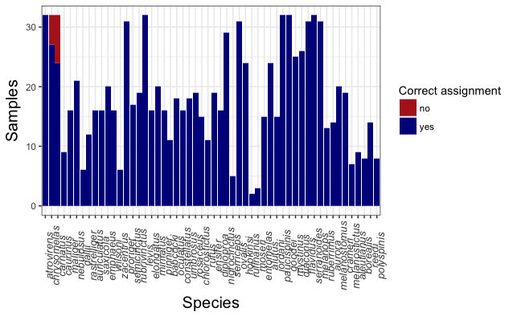

```r
assign_plot1 <- second_assign %>%
  filter(scaled_likelihood > 0.5) %>%
  mutate(correct = ifelse(collection == inferred_collection, "yes", "no")) %>%
  select(indiv, collection, inferred_collection, scaled_likelihood, correct) %>%
  group_by(collection, correct) %>%
  tally() %>%
  ggplot(aes(x = collection, y = n, fill = correct)) +
  geom_bar(stat = "identity") +
  theme_bw() +
  xlab("Species") +
  ylab("Samples") +
  scale_fill_manual(values = c("firebrick", "darkblue")) +
  guides(fill=guide_legend(title="Correct assignment"))
assign_plot1 +
  theme(
    axis.text.x = element_text(angle = 90, face = "italic", size = 10),
     axis.title = element_text(size = 15, margin = margin(t = 0, r = 20, b = 0, l = 0))
  )
ggsave("pdf_outputs/genetic_assignment_50.pdf", height = 4, width = 8)
```

What about at the 95% threshold?

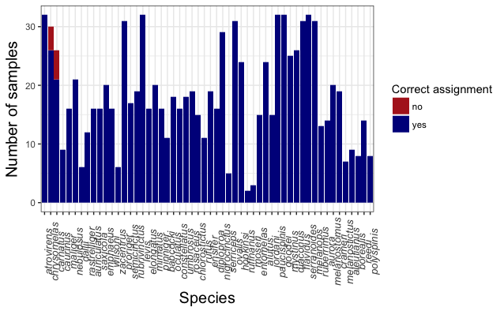

```r
assign_plot2 <- second_assign %>%
  filter(scaled_likelihood > 0.95) %>%
  mutate(correct = ifelse(collection == inferred_collection, "yes", "no")) %>%
  select(indiv, collection, inferred_collection, scaled_likelihood, correct) %>%
  group_by(collection, correct) %>%
  tally() %>%
  ggplot(aes(x = collection, y = n, fill = correct)) +
  geom_bar(stat = "identity") +
  theme_bw() +
  xlab("Species") +
  ylab("Number of samples") +
  scale_fill_manual(values = c("firebrick", "darkblue")) +
  guides(fill=guide_legend(title="Correct assignment"))
assign_plot2 +
  theme(
    axis.text.x = element_text(angle = 90, face = "italic", size = 10),
    axis.title = element_text(size = 15, margin = margin(t = 0, r = 20, b = 0, l = 0))
  )
ggsave("pdf_outputs/genetic_assignment_95.pdf", height = 4, width = 8)
```

Try proportion:

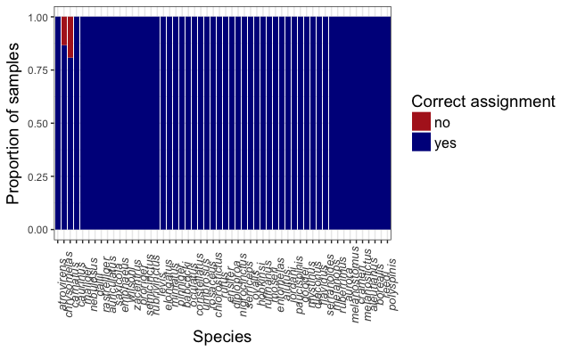

```r
prop_plot <- second_assign %>%
  filter(scaled_likelihood > 0.95) %>%
  mutate(correct = ifelse(collection == inferred_collection, "yes", "no")) %>%
  select(indiv, collection, inferred_collection, scaled_likelihood, correct) %>%
  group_by(collection, correct) %>%
  tally() %>%
  ungroup() %>%
  group_by(collection) %>%
  mutate(proportion = n/(sum(n))) %>%
  ggplot(aes(x = collection, y = proportion, fill = correct)) +
  geom_bar(stat = "identity") +
  theme_bw() +
  xlab("Species") +
  ylab("Proportion of samples") +
  scale_fill_manual(values = c("firebrick", "darkblue")) +
  guides(fill=guide_legend(title="Correct assignment"))
prop_plot +
  theme(
    axis.text.x = element_text(angle = 90, face = "italic", size = 10),
    axis.title = element_text(size = 14),
    legend.text = element_text(size = 12),
    legend.title = element_text(size = 14)
  )
ggsave("pdf_outputs/prop_genetic_assignment_95.pdf", height = 5, width = 8)
```

Combine the two:

```r
lower_like <- second_assign %>%
  filter(scaled_likelihood > 0.5) %>%
  mutate(correct = ifelse(collection == inferred_collection, "yes", "no")) %>%
  select(indiv, collection, inferred_collection, scaled_likelihood, correct) %>%
  group_by(collection, correct) %>%
  tally()
high_like <- second_assign %>%
  filter(scaled_likelihood > 0.95) %>%
  mutate(correct = ifelse(collection == inferred_collection, "yes", "no")) %>%
  select(indiv, collection, inferred_collection, scaled_likelihood, correct) %>%
  group_by(collection, correct) %>%
  tally()
hlik <- high_like %>%
  spread(key = correct, value = n)
llik <- lower_like %>%
  spread(key = correct, value = n)
combo %>%
  rename(correct_50 = correct.x) %>%
  rename(correct_95 = correct.y) %>%

library(reshape2)
```

```
Error in eval(expr, envir, enclos) : object 'combo' not found
```

## single GBY reporting unit

Since all of the misassignments are GBY, make a single reporting unit.

```r
# change the carnatus reporting unit to chrysomelas
gby_repu_2col <- down_data2 %>%
  mutate(repunit = ifelse(repunit == "carnatus", "chrysomelas", repunit))
# confirm that the repunit is changed but the collection is not.
gby_repu_2col %>%
  filter(collection == "carnatus")
```

| sample_type | repunit | collection | indiv | Plate_1_A01_Sat_GW603857_consensus.1 | Plate_1_A01_Sat_GW603857_consensus.2 | Plate_1_A11_Sat_GE820299_consensus.1 | Plate_1_A11_Sat_GE820299_consensus.2 | Plate_2_A09_Sat_EW986980_consensus.1 | Plate_2_A09_Sat_EW986980_consensus.2 | Plate_2_C08_Sat_EW987116_consensus.1 | Plate_2_C08_Sat_EW987116_consensus.2 | Plate_2_G06_Sat_EW987118_consensus.1 | Plate_2_G06_Sat_EW987118_consensus.2 | Plate_3_C03_Sat_GE798118_consensus.1 | Plate_3_C03_Sat_GE798118_consensus.2 | Plate_4_E10_Sat_EW976030_consensus.1 | Plate_4_E10_Sat_EW976030_consensus.2 | Plate_4_G06_Sat_EW976181_consensus.1 | Plate_4_G06_Sat_EW976181_consensus.2 | tag_id_1049.1 | tag_id_1049.2 | tag_id_108.1 | tag_id_108.2 | tag_id_1184.1 | tag_id_1184.2 | tag_id_1229.1 | tag_id_1229.2 | tag_id_1272.1 | tag_id_1272.2 | … |
| --- | --- | --- | --- | --- | --- | --- | --- | --- | --- | --- | --- | --- | --- | --- | --- | --- | --- | --- | --- | --- | --- | --- | --- | --- | --- | --- | --- | --- | --- | --- |
| reference | chrysomelas | carnatus | R035371 | 1 | 1 | 3 | 3 | 2 | 4 | 1 | 1 | 1 | 5 | 1 | 1 | 6 | 7 | 5 | 5 | 1 | 11 | 16 | 16 | 5 | 8 | 1 | 9 | 1 | 8 | … |
| reference | chrysomelas | carnatus | R011749 | 1 | 1 | 2 | 3 | 1 | 2 | 1 | 5 | 11 | 13 | 1 | 1 | 6 | 7 | 5 | 5 | 1 | 11 | 1 | 3 | 8 | 8 | 1 | 1 | 1 | 1 | … |
| reference | chrysomelas | carnatus | R011738 | 1 | 5 | 3 | 10 | 1 | 1 | 1 | 1 | 5 | 5 | 5 | 5 | 6 | 7 | 5 | 5 | 1 | 11 | 7 | 7 | 5 | 8 | 9 | 9 | 1 | 2 | … |
| reference | chrysomelas | carnatus | R035416 | 1 | 1 | 2 | 3 | 4 | 4 | 1 | 5 | 1 | 5 | 1 | 5 | 6 | 7 | 5 | 5 | 1 | 1 | 16 | 16 | 5 | 8 | 1 | 1 | 1 | 1 | … |
| reference | chrysomelas | carnatus | R035440 | 1 | 1 | 3 | 20 | 1 | 4 | 1 | 1 | 5 | 11 | 1 | 1 | 6 | 7 | 5 | 5 | 1 | 11 | 7 | 7 | 5 | 7 | 1 | 9 | 1 | 2 | … |
| reference | chrysomelas | carnatus | R035534 | 1 | 1 | 3 | 3 | 1 | 4 | 1 | 5 | 1 | 1 | 1 | 5 | 6 | 9 | 5 | 5 | 11 | 11 | 1 | 7 | 5 | 8 | 1 | 9 | 1 | 8 | … |
| reference | chrysomelas | carnatus | R035396 | 1 | 1 | 3 | 3 | 1 | 4 | 1 | 1 | 5 | 11 | 1 | 1 | 6 | 6 | 5 | 5 | 1 | 11 | 7 | 7 | 5 | 8 | 1 | 1 | 1 | 1 | … |
| reference | chrysomelas | carnatus | R035395 | 1 | 1 | 2 | 3 | 1 | 4 | 1 | 5 | 1 | 5 | 5 | 14 | 6 | 6 | 5 | 5 | 1 | 11 | 16 | 16 | 6 | 6 | 1 | 9 | 1 | 1 | … |
| reference | chrysomelas | carnatus | R035489 | 1 | 2 | 3 | 3 | 2 | 4 | 1 | 1 | 1 | 5 | 1 | 1 | 6 | 6 | 5 | 19 | 1 | 1 | 1 | 16 | 5 | 6 | 1 | 9 | 1 | 1 | … |
| reference | chrysomelas | carnatus | R035360 | 1 | 1 | 2 | 3 | 1 | 2 | 1 | 1 | 1 | 11 | 1 | 13 | 6 | 7 | 5 | 5 | 11 | 11 | 7 | 16 | 5 | 5 | 1 | 9 | 2 | 15 | … |

[output cut: 22 more lines]

Now try self-assignment with the single reporting unit

```r
gby_repu_assigned <- gby_repu_2col %>%
  self_assign(., gen_start_col = 5)
```

```
Summary Statistics:

997 Individuals in Sample

90 Loci: Plate_1_A01_Sat_GW603857_consensus.1, Plate_1_A11_Sat_GE820299_consensus.1, Plate_2_A09_Sat_EW986980_consensus.1, Plate_2_C08_Sat_EW987116_consensus.1, Plate_2_G06_Sat_EW987118_consensus.1, Plate_3_C03_Sat_GE798118_consensus.1, Plate_4_E10_Sat_EW976030_consensus.1, Plate_4_G06_Sat_EW976181_…

53 Reporting Units: aleutianus, alutus, auriculatus, aurora, babcocki, borealis, caurinus, chlorostictus, constellatus, crameri, dallii, diaconus, diploproa, elongatus, emphaeus, ensifer, entomelas, flavidus, hopkinsi, jordani, maliger, melanops, melanostictus, melanostomus, miniatus, moseri, mystin…

54 Collections: aleutianus, alutus, auriculatus, aurora, babcocki, borealis, caurinus, chlorostictus, constellatus, crameri, dallii, diaconus, diploproa, elongatus, emphaeus, ensifer, entomelas, flavidus, hopkinsi, jordani, maliger, melanops, melanostictus, melanostomus, miniatus, moseri, mystinus, …

8.5712693636465% of allelic data identified as missing
```

Accuracy?

```r
gby_repu_assigned %>%
  group_by(indiv) %>%
  top_n(1, scaled_likelihood) %>% # just the top assignments for each individual
  #filter(scaled_likelihood < 0.95 & scaled_likelihood > 0.5) %>%
  filter(repunit == inferred_repunit) %>%
  filter(scaled_likelihood < 0.95)
```

| indiv | collection | repunit | inferred_collection | inferred_repunit | scaled_likelihood | log_likelihood | z_score | n_non_miss_loci | n_miss_loci | missing_loci |
| --- | --- | --- | --- | --- | --- | --- | --- | --- | --- | --- |
| R035534 | carnatus | chrysomelas | carnatus | chrysomelas | 0.7016643 | -114.62175 | 1.8116621 | 90 | 0 |  |
| R035396 | carnatus | chrysomelas | carnatus | chrysomelas | 0.6054156 | -149.03368 | -0.4499607 | 90 | 0 |  |
| R035360 | carnatus | chrysomelas | chrysomelas | chrysomelas | 0.5515163 | -130.37798 | 0.1850846 | 82 | 8 |  |
| R035529 | carnatus | chrysomelas | chrysomelas | chrysomelas | 0.6359021 | -127.95047 | 1.4430332 | 89 | 1 |  |
| R035511 | carnatus | chrysomelas | chrysomelas | chrysomelas | 0.6984545 | -97.14617 | 0.5123135 | 68 | 22 |  |
| R035517 | carnatus | chrysomelas | carnatus | chrysomelas | 0.6490196 | -168.86579 | -1.7533678 | 90 | 0 |  |
| R011763 | chrysomelas | chrysomelas | chrysomelas | chrysomelas | 0.6028517 | -166.80595 | -0.9849872 | 90 | 0 |  |
| R012043 | chrysomelas | chrysomelas | carnatus | chrysomelas | 0.5112458 | -176.67472 | -2.2665870 | 90 | 0 |  |

```r
989/997
```

```
[1] 0.9919759
```

```r
gby_repu_assigned %>%
  filter(scaled_likelihood > 0.5 & scaled_likelihood < 0.95)
```

| indiv | collection | repunit | inferred_collection | inferred_repunit | scaled_likelihood | log_likelihood | z_score | n_non_miss_loci | n_miss_loci | missing_loci |
| --- | --- | --- | --- | --- | --- | --- | --- | --- | --- | --- |
| R035534 | carnatus | chrysomelas | carnatus | chrysomelas | 0.7016643 | -114.62175 | 1.8116621 | 90 | 0 |  |
| R035396 | carnatus | chrysomelas | carnatus | chrysomelas | 0.6054156 | -149.03368 | -0.4499607 | 90 | 0 |  |
| R035360 | carnatus | chrysomelas | chrysomelas | chrysomelas | 0.5515163 | -130.37798 | 0.1850846 | 82 | 8 |  |
| R035529 | carnatus | chrysomelas | chrysomelas | chrysomelas | 0.6359021 | -127.95047 | 1.4430332 | 89 | 1 |  |
| R035511 | carnatus | chrysomelas | chrysomelas | chrysomelas | 0.6984545 | -97.14617 | 0.5123135 | 68 | 22 |  |
| R035517 | carnatus | chrysomelas | carnatus | chrysomelas | 0.6490196 | -168.86579 | -1.7533678 | 90 | 0 |  |
| R011763 | chrysomelas | chrysomelas | chrysomelas | chrysomelas | 0.6028517 | -166.80595 | -0.9849872 | 90 | 0 |  |
| R012043 | chrysomelas | chrysomelas | carnatus | chrysomelas | 0.5112458 | -176.67472 | -2.2665870 | 90 | 0 |  |

All assignments below the 95% threshold were gopher/black-and-yellow.

Make the same plot with the single reporting unit:

```r
# and set the levels explicitly
gby_repu_assigned$repunit <- factor(gby_repu_assigned$repunit, levels = c("atrovirens", "chrysomelas", "carnatus", "caurinus", "maliger", "nebulosus", "dallii","rastrelliger", "auriculatus", "saxicola", "emphaeus", "wilsoni", "zacentrus", "proriger", "semicinctus", "rubrivinctus", "levis", "elongatus", "miniatus", "pinniger", "babcocki", "oculatus", "constellatus", "umbrosus", "rosaceus", "chlorostictus", "rufus", "ensifer", "diploproa", "nigrocinctus", "serriceps", "ovalis", "hopkinsi", "rufinanus", "moseri", "entomelas", "alutus", "jordani", "paucispinis", "goodei", "mystinus", "diaconus", "flavidus", "serranoides", "melanops", "ruberrimus", "aurora", "melanostomus", "crameri", "melanostictus", "aleutianus", "borealis", "reedi", "polyspinis"))
```

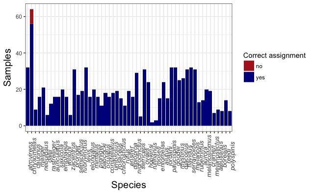

```r
gby_assign_plot <- gby_repu_assigned %>%
  filter(scaled_likelihood > 0.5) %>%
  mutate(correct = ifelse(scaled_likelihood > 0.95, "yes", "no")) %>%
  #mutate(correct = ifelse(repunit == inferred_repunit, "yes", "no")) %>%
  select(indiv, collection, repunit, inferred_repunit, scaled_likelihood, correct) %>%
  group_by(repunit, correct) %>%
  tally() %>%
  ggplot(aes(x = repunit, y = n, fill = correct)) +
  geom_bar(stat = "identity") +
  theme_bw() +
  xlab("Species") +
  ylab("Samples") +
  scale_fill_manual(values = c("firebrick", "darkblue")) +
  guides(fill=guide_legend(title="Correct assignment"))
gby_assign_plot +
  theme(
    axis.text.x = element_text(angle = 90, face = "italic", size = 10),
     axis.title = element_text(size = 15, margin = margin(t = 0, r = 20, b = 0, l = 0))
  )
ggsave("pdf_outputs/gby_genetic_assignment_95.pdf", height = 4, width = 8)
```

What about z-statistics?

```r
gby_repu_assigned %>%
  ungroup() %>%
  filter(scaled_likelihood > 0.5 & z_score < -3)
```

| indiv | collection | repunit | inferred_collection | inferred_repunit | scaled_likelihood | log_likelihood | z_score | n_non_miss_loci | n_miss_loci | missing_loci |
| --- | --- | --- | --- | --- | --- | --- | --- | --- | --- | --- |

No outliers. That’s nice and much cleaner.

Let’s grab information for those samples

```r
clean_samples <- gby_repu_assigned %>%
  ungroup() %>%
  filter(collection == inferred_collection) %>%
  select(indiv, collection) %>%
  ungroup()
```

997 samples in total.

Final tally/summary

```r
clean_samples %>%
  group_by(collection) %>%
  tally() %>%
  rename(species = collection) %>%
  right_join(., spp_tally5) %>%
  rename(final_dataset = n) %>%
  select(species, n_genotyped, post_filter, juv_removed, downsampled, final_dataset) %>%
  arrange(desc(final_dataset)) %>%
  write_csv("csv_outputs/final_species_tally_manuscript_v2.csv")
```

## Grab this dataset for a PCA

Modified 2-column format

## calculate and plot int hz for each species

I want to use this same dataset of 997 individuals for calculating int-hz.

```r
t1 <- clean_samples %>%
  left_join(down_data2) %>%
  group_by(indiv, collection) %>%
  select(-sample_type, -repunit) %>%
  gather(locus, allele, 3:182) %>%
  ungroup() %>% # need to remove the .1 and .2 on the loci
  separate(locus, c("Locus", "gene.copy"), sep = "[.]")
```

```r
int_hz <- t1 %>%
  group_by(collection, indiv, Locus) %>%
  summarise(hz = allele[1]!=allele[2]) %>%
  filter(!is.na(hz)) %>%
  group_by(indiv, collection) %>%
  summarise(num_loc = n(), num_hz = sum(hz), fract_hz = num_hz / num_loc)
```

Read in the file with expected Hz (from MS toolkit) to confirm that the numbers are equivalent.

```r
hz_ex <- read_csv("csv_outputs/expected_Hz_fromMStoolkit.csv")
hz_ex
```

| species | expected_Hz |
| --- | --- |
| atrovirens | 0.47516984 |
| chrysomelas | 0.44468390 |
| carnatus | 0.42573329 |
| maliger | 0.32006672 |
| ensifer | 0.27540002 |
| rosaceus | 0.27451772 |
| caurinus | 0.24901302 |
| chlorostictus | 0.21369301 |
| melanostictus | 0.20921617 |
| umbrosus | 0.19881184 |

[output cut: 44 more lines]

## What about making a series of boxplots?

Summary Statistics The lower and upper hinges correspond to the first and third quartiles (the 25th and 75th percentiles).

The upper whisker extends from the hinge to the largest value no further than 1.5 x IQR from the hinge (where IQR is the inter-quartile range, or distance between the first and third quartiles). The lower whisker extends from the hinge to the smallest value at most 1.5 x IQR of the hinge. Data beyond the end of the whiskers are called “outlying” points and are plotted individually. Now what about adding in the subgenera and coloring the boxes by that?

Make a list of subgenera and species and read that in

```r
subgenera <- read_csv("../data/sebastes_subgenera.csv")
```

```r
int_hz_subg <- int_hz %>%
  ungroup() %>%
  left_join(., subgenera, by = c("collection" = "species"))
# and set the levels explicitly again
int_hz_subg$collection <- factor(int_hz_subg$collection, levels = c("atrovirens", "chrysomelas", "carnatus", "caurinus", "maliger", "nebulosus", "dallii","rastrelliger", "auriculatus", "saxicola", "emphaeus", "wilsoni", "zacentrus", "proriger", "semicinctus", "rubrivinctus", "levis", "elongatus", "miniatus", "pinniger", "babcocki", "oculatus", "constellatus", "umbrosus", "rosaceus", "chlorostictus", "rufus", "ensifer", "diploproa", "nigrocinctus", "serriceps", "ovalis", "hopkinsi", "rufinanus", "moseri", "entomelas", "alutus", "jordani", "paucispinis", "goodei", "mystinus", "diaconus", "flavidus", "serranoides", "melanops", "ruberrimus", "aurora", "melanostomus", "crameri", "melanostictus", "aleutianus", "borealis", "reedi", "polyspinis"))
```

Change the colors:

```r
library(RColorBrewer)
# subgenera colors
#mycolors = colorRampPalette(brewer.pal(name="Accent", n = 8))(15)
# mycolors = c("palegreen", "darkseagreen", "darkblue", "dodgerblue",  "steelblue4", "skyblue", "brown", "royalblue", "purple4", "orange", "chocolate", "saddlebrown", "navajowhite4", "darkgray", "black")
#
# # species colors
# mycol <- colorRampPalette(c("palegreen", "darkolivegreen", "darkslategrey", "darkgreen", "deepskyblue", "aquamarine4", "seagreen4", "cadetblue", "cyan", "darkblue", "midnightblue", "blue", "dodgerblue", "darkcyan", "darkslateblue", "slateblue", "steelblue4", "skyblue", "paleturquoise4", "brown", "royalblue", "purple4", "orange", "darkorange", "darkgoldenrod", "chocolate", "tan4", "saddlebrown", "sienna", "navajowhite4", "darkgray", "black"))(54)
```

Set the subgenera to the order of the factor (species)

```r
int_hz2 <- int_hz_subg %>%
  ungroup()
int_hz2$subgenus <- factor(int_hz2$subgenus, levels = c("Pteropodus", "Auctospina", "Allosebastes", "Hispaniscus", "Rosicola", "Sebastomus", "Sebastichthys", "Sebastocarus", "Acutomentum", "Sebastodes", "Sebastosomus", "Sebastopyr", "Eosebastes", "Zalopyr", "unclassified"))
```

## New colors for July 2019

```r
mycolors = c("darkgreen", "dodgerblue", "darkblue", "chartreuse", "aquamarine", "deeppink", "firebrick4", "orchid", "purple4", "orange", "orangered", "saddlebrown", "navajowhite4", "darkgray", "black")
```

```r
ggsave("pdf_outputs/sebastes_int_hz_new_colors.pdf", width = 8, height = 6)
```

update: Carlos wanted this plot ordered by int hz not by subgenus.

Try using the subgenera for plotting genetic distance:

```r
dist <- read_csv("~/Desktop/sebastes_sppID/sebastes_genetic_distance_summary.csv")

# group by model
dist1 <- dist %>%
  group_by(model_type)
```

```r
# join expected Hz and genetic distance
dist_hz2 <- dist1 %>%
  left_join(., hz_ex) %>%
  left_join(., subgenera)

hz_ex %>%
  arrange(desc(expected_Hz))


# and set the levels
dist_hz2$subgenus <- factor(dist_hz2$subgenus, levels = c("Pteropodus", "Auctospina", "Allosebastes", "Hispaniscus", "Rosicola", "Sebastomus", "Sebastichthys", "Sebastocarus", "Acutomentum", "Sebastodes", "Sebastosomus", "Sebastopyr", "Eosebastes", "Zalopyr", "unclassified"))

levels(dist_hz2$subgenus)
```

```r
# italicize atrovirens in the axis title
my_x_title <- expression(paste("Genetic distance from ", italic("S. atrovirens")))

# plot
d2 <- dist_hz2 %>%
  filter(model_type == "pairwise_analytic") %>%
  ggplot(aes(x = genetic_distance, y = expected_Hz, color = subgenus)) +
  geom_point(size = 2, alpha = 0.9) +
  theme_bw() +
  scale_color_manual(values = mycolors) +
  xlab(my_x_title) +
  ylab("Heterozygosity")

d2 + theme(
  legend.text = element_text(size = 8, face = "italic")) +
  guides(color = guide_legend(title="Subgenus"))

# save that plot
ggsave("pdf_outputs/subgenera_genetic_distance_v_expected_hz.pdf", width = 7, height = 5)
```

Play with the species as individuals shapes within the subgenera?

Maybe that would be levels within the subgenera “factors”?

```r
p1 <- dist_hz %>%
  filter(model_type == "pairwise_analytic") %>%
  ggplot(aes(x = genetic_distance, y = expected_Hz, color = species)) +
  geom_point() +
  theme_bw() +
  scale_color_manual(values = mycol) +
  xlab("Genetic distance") +
  ylab("Heterozygosity")

p1 + facet_wrap(. ~subgenus, nrow = 5, ncol = 3)
```

This defeats the purpose of seeing the decline in heterozygosity over genetic distance.

## Missing data

Carlos wants a table of how many loci are missing from which species - let’s see if we can tally that up.

| species | locus | n | missing_loci | total_samples | perc |
| --- | --- | --- | --- | --- | --- |
| aleutianus | Plate_2_G06_Sat_EW987118_consensus | 16 | 8 | 9 | 88.888889 |
| aleutianus | Plate_4_E10_Sat_EW976030_consensus | 12 | 6 | 9 | 66.666667 |
| aleutianus | tag_id_1272 | 2 | 1 | 9 | 11.111111 |
| aleutianus | tag_id_1399 | 18 | 9 | 9 | 100.000000 |
| aleutianus | tag_id_1449 | 6 | 3 | 9 | 33.333333 |
| aleutianus | tag_id_1471 | 18 | 9 | 9 | 100.000000 |
| aleutianus | tag_id_1558 | 2 | 1 | 9 | 11.111111 |
| aleutianus | tag_id_1652 | 18 | 9 | 9 | 100.000000 |
| aleutianus | tag_id_1762 | 16 | 8 | 9 | 88.888889 |
| aleutianus | tag_id_1810 | 18 | 9 | 9 | 100.000000 |

[output cut: 968 more lines]

There are only 83 loci in that table, suggesting that there are some loci that are never missing in any species (in our final 997 sample dataset).

out of curiosity do they actually not amplify in those species?

```r
library(feather)
raw1 <- read_feather("../new_baseline_data/feather_files/gtseq66_sebastes_spp_10292018.feather")

raw1 %>%
  filter(id == "s2290") %>%
  select(locus, depth) %>%
  group_by(locus) %>%
  arrange(locus) %>%
  top_n(., 2) %>%
  filter(locus == "tag_id_1810")
```

Yes.

Can we figure out which loci those are?

| locus | species | n | missing_loci | total_samples | perc |
| --- | --- | --- | --- | --- | --- |
| Plate_1_A01_Sat_GW603857_consensus | NA | NA | NA | NA | NA |
| Plate_1_A11_Sat_GE820299_consensus | carnatus | 2 | 1 | 32 | 3.125000 |
| Plate_2_A09_Sat_EW986980_consensus | nigrocinctus | 2 | 1 | 29 | 3.448276 |
| Plate_2_C08_Sat_EW987116_consensus | NA | NA | NA | NA | NA |
| Plate_2_G06_Sat_EW987118_consensus | aleutianus | 16 | 8 | 9 | 88.888889 |
| Plate_2_G06_Sat_EW987118_consensus | flavidus | 26 | 13 | 31 | 41.935484 |
| Plate_2_G06_Sat_EW987118_consensus | melanops | 36 | 18 | 31 | 58.064516 |
| Plate_2_G06_Sat_EW987118_consensus | melanostictus | 14 | 7 | 7 | 100.000000 |
| Plate_3_C03_Sat_GE798118_consensus | nigrocinctus | 58 | 29 | 29 | 100.000000 |
| Plate_3_C03_Sat_GE798118_consensus | reedi | 2 | 1 | 14 | 7.142857 |

[output cut: 981 more lines]

What about a summary of how many loci failed entirely in a given species?

| species | n |
| --- | --- |
| aleutianus | 5 |
| alutus | 8 |
| auriculatus | 1 |
| aurora | 2 |
| babcocki | 5 |
| borealis | 9 |
| chlorostictus | 5 |
| constellatus | 4 |
| crameri | 9 |
| dallii | 2 |

[output cut: 39 more lines]

add all species to the table

```r
spps <- c1 %>%
  ungroup() %>%
  select(species) %>%
  unique()

missing_ones <- spps %>%
  ungroup() %>%
  left_join(., goners) %>%
  mutate_all(funs(replace(., is.na(.), 0))) %>%
  left_join(., subgenera)


# and set the levels explicitly
missing_ones$species <- factor(missing_ones$species, levels = c("atrovirens", "chrysomelas", "carnatus", "caurinus", "maliger", "nebulosus", "dallii","rastrelliger", "auriculatus", "saxicola", "emphaeus", "wilsoni", "zacentrus", "proriger", "semicinctus", "rubrivinctus", "levis", "elongatus", "miniatus", "pinniger", "babcocki", "oculatus", "constellatus", "umbrosus", "rosaceus", "chlorostictus", "rufus", "ensifer", "diploproa", "nigrocinctus", "serriceps", "ovalis", "hopkinsi", "rufinanus", "moseri", "entomelas", "alutus", "jordani", "paucispinis", "goodei", "mystinus", "diaconus", "flavidus", "serranoides", "melanops", "ruberrimus", "aurora", "melanostomus", "crameri", "melanostictus", "aleutianus", "borealis", "reedi", "polyspinis"))

levels(missing_ones$species)
```

```r
# subgenus colors
# mycolors = c("palegreen", "darkseagreen", "darkblue", "dodgerblue",  "steelblue4", "skyblue", "brown", "royalblue", "purple4", "orange", "chocolate", "saddlebrown", "navajowhite4", "darkgray", "black")
# and set the subgenus levels
missing_ones$subgenus <- factor(missing_ones$subgenus, levels = c("Pteropodus", "Auctospina", "Allosebastes", "Hispaniscus", "Rosicola", "Sebastomus", "Sebastichthys", "Sebastocarus", "Acutomentum", "Sebastodes", "Sebastosomus", "Sebastopyr", "Eosebastes", "Zalopyr", "unclassified"))
levels(missing_ones$subgenus)
```

```
 [1] "Pteropodus"    "Auctospina"    "Allosebastes"  "Hispaniscus"   "Rosicola"
 [6] "Sebastomus"    "Sebastichthys" "Sebastocarus"  "Acutomentum"   "Sebastodes"
[11] "Sebastosomus"  "Sebastopyr"    "Eosebastes"    "Zalopyr"       "unclassified"
```

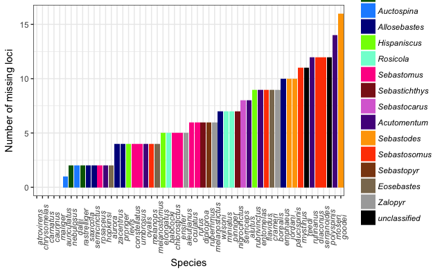

```r
# quick plot?
mplot <- ggplot(missing_ones, aes(x = reorder(species, n), y = n, fill = subgenus)) +
  geom_bar(stat = "identity") +
  theme_bw() +
  ylab("Number of missing loci") +
  xlab("Species") +
  scale_fill_manual(values = mycolors)

mplot +
  theme(
    axis.text.x = element_text(angle = 90, face = "italic"),
    legend.text = element_text(face = "italic")
  )
```

```r
#ggsave("pdf_outputs/missing_loci_plot_new_colors.pdf", height = 6, width = 8)
```

## Additions to Table 1

I want to amend Table 1 to include nucleotide diversity and internal heterozygosity for each species

```r
clean_samples %>%
  group_by(collection) %>%
  tally() %>%
  rename(species = collection) %>%
  left_join(., pi) %>%
  left_join(., mean_hz) %>%
  left_join(., subgenera) %>%
  select(-Li_etal) %>%
  arrange(desc(nuc_diversity))
```

```
Column `species` joining character vector and factor, coercing into character vectorJoining, by = "species"
```

| species | n | nuc_diversity | int_hz | subgenus |
| --- | --- | --- | --- | --- |
| atrovirens | 32 | 0.0067804192 | 0.45781055 | Pteropodus |
| chrysomelas | 32 | 0.0059204394 | 0.40858692 | Pteropodus |
| carnatus | 32 | 0.0056091117 | 0.40317897 | Pteropodus |
| rosaceus | 19 | 0.0046720945 | 0.22752919 | Sebastomus |
| maliger | 16 | 0.0043282573 | 0.32847312 | Pteropodus |
| ensifer | 19 | 0.0039266965 | 0.23618045 | Sebastomus |
| chlorostictus | 15 | 0.0036761798 | 0.18289617 | Sebastomus |
| constellatus | 16 | 0.0035381582 | 0.14734552 | Sebastomus |
| melanostictus | 7 | 0.0035273466 | 0.18143432 | Zalopyr |
| caurinus | 9 | 0.0034347069 | 0.23362397 | Pteropodus |

[output cut: 44 more lines]

# calculate stats for nuc diversity

```r
44/54
```

```
[1] 0.8148148
```